# Travel Time Matrix to Maps

## Notebook Purpose

This notebook serves to summarize the entire visualization process going from the travel time matrix to the visualizations. That involves the following sections:

1. Travel Time Matrix Wrangling
2. Score Computation
3. Isochrone Computation
4. Dataset Wrangling Part II (NA Insertion)
5. Interactive Visualization
6. Map HTML Exports

## 0) Useful Libraries

```r
# import custom scoring, cleaning, and visualization functions
source('functions.R')

# wrangling/convenience
library(tidyverse)
library(glue)
library(stringr)
library(sf)
library(data.table)
library(bit64)

# visualization
library(leaflet)
library(mapview); mapviewOptions(platform = 'leafgl')

# For pretty knitting
library(lemon)
knit_print.data.frame <- lemon_print
knit_print.tbl <- lemon_print
knit_print.summary <- lemon_print
```

## 1) Data Wrangling

### Import all dissemination block data

```r
# import dissemination blocks and keep id and pop columns
origins <- fread(file.path("../../data/clean", "vancouver_db.csv"))[, .(id, pop, lat, lon)]
origins$pop <- str_replace_all(origins$pop, ',', '')

# change col types
origins$pop <- as.numeric(origins$pop)
origins$id <- as.factor(origins$id)
n_origins <- nrow(origins)
paste('Origin Rows: ', n_origins)
```

```
[1] "Origin Rows:  15197"
```

```r
# Peek
head(origins)
```

| id | pop | lat | lon |
| --- | --- | --- | --- |
| 59150004004 | 35 | 49.3739 | -123.2738 |
| 59150004005 | 50 | 49.3746 | -123.2757 |
| 59150004006 | 94 | 49.3738 | -123.2763 |
| 59150004011 | 0 | 49.3735 | -123.2725 |
| 59150004012 | 0 | 49.3725 | -123.2729 |
| 59150004013 | 0 | 49.3724 | -123.2728 |

### Import all amenity data

```r
# import amenities (Cultural/Art facilities)
destinations <- fread(file.path("../../data/clean", "vancouver_facilities_2.csv"))

# see summary counts of each amenity
destinations %>% group_by(type) %>% summarise(count = n()) %>% arrange(desc(count))
```

| type | count |
| --- | --- |
| gallery | 99 |
| museum | 92 |
| library or archives | 88 |
| theatre/performance and concert hall | 75 |
| artist | 48 |
| heritage or historic site | 28 |
| miscellaneous | 6 |
| art or cultural centre | 5 |
| festival site | 2 |

```r
# clean amenities / filter types to keep 4 most frequent amenities
target_amenities <- c('gallery', 'museum', 'library or archives', 'theatre/performance and concert hall')
destinations <- destinations %>% filter(type %in% target_amenities)
# keep only id and type columns
destinations <- destinations[ , .(id, type)]
# change col types
destinations$type <- as.factor(destinations$type)
destinations$id <- as.factor(destinations$id)

n_amenities <- nrow(destinations)
paste('Destinations: ', n_amenities)
```

```
[1] "Destinations:  354"
```

```r
head(destinations)
```

| id | type |
| --- | --- |
| 10 | museum |
| 15 | museum |
| 24 | museum |
| 115 | library or archives |
| 157 | gallery |
| 215 | library or archives |

### Import the travel time matrix

```r
# import travel time matrix
ttm <- fread(file.path('../../data/clean', 'ttm.csv'))

# convert Ids to  factor
ttm$fromId <- as.factor(ttm$fromId)
ttm$toId <- as.factor(ttm$toId)

## Replace travel times less than 1 minute to 1 minute
# This is done to prevent infinity values in the scoring since
# 1 minute is still a reasonable time for trips in the 0 - 1 min range.
ttm$avg_time <- pmax(ttm$avg_time, 1)

# peek
head(ttm)
```

| fromId | toId | avg_time | sd_time |
| --- | --- | --- | --- |
| 59150004004 | 10 | 99.76316 | 5.364721 |
| 59150004004 | 15 | 72.48718 | 3.401794 |
| 59150004004 | 157 | 96.69231 | 3.001349 |
| 59150004004 | 1759 | 106.82051 | 4.388213 |
| 59150004004 | 1760 | 46.58974 | 2.642944 |
| 59150004004 | 1822 | 76.64103 | 3.990035 |

### Import amenity weights:

```r
# import amenity weights
amenity_wts <- read.csv('../../data/amenity_weights/amenity_wts.csv')
amenity_wts
```

| id | weight |
| --- | --- |
| 2292 | 0.47152527 |
| 2692 | 0.68622291 |
| 4546 | 0.67131509 |
| 6749 | 0.56921656 |
| 7153 | 0.80317625 |
| 7806 | 0.56940367 |
| 8165 | 0.57201653 |
| 8963 | 0.49582701 |
| 9118 | 0.38925919 |
| 9336 | 0.64820159 |

[output cut: 430 more lines]

```r
# clean weights

amenity_wts$id <-  as.factor(amenity_wts$id)

amenity_wts %>% group_by(id) %>% summarize(n = n()) %>% arrange(desc(n))
```

| id | n |
| --- | --- |
| 10 | 1 |
| 15 | 1 |
| 24 | 1 |
| 41 | 1 |
| 97 | 1 |
| 115 | 1 |
| 123 | 1 |
| 157 | 1 |
| 213 | 1 |
| 215 | 1 |

[output cut: 430 more lines]

```r
# Check: are all the ttm amenity IDs in the weighted IDs set?
check <- all(unique(ttm$toId) %in% unique(amenity_wts$id))
# needs to be true for the join to work
paste('Are all the ttm amenity IDs in the weighted IDs set? =', check)
```

```
[1] "Are all the ttm amenity IDs in the weighted IDs set? = TRUE"
```

### Fixed unequal number of ttm amenity IDs in the weighted IDs If check == False

```r
if (check == F){
# ttm ids that appear in the weights ids
ttm_id_in_wts <- unique(ttm$toId)[unique(ttm$toId) %in% unique(amenity_wts$id)]

# subset these id that not in amenity wts
ttm_id_not_in_wts <- unique(subset(ttm, !(toId %in% ttm_id_in_wts))$toId)
ttm_id_not_in_wts <- as.data.frame(list("id_not_in_wts" = ttm_id_not_in_wts))

paste('Number of id that not in amenity wts ', ttm_id_not_in_wts %>% nrow())


# assign minimum weight on those places
ttm_id_not_in_wts$weight <- min(amenity_wts$weight)
colnames(ttm_id_not_in_wts)[1] <- "id"

# add it to amenity weights
amenity_wts <- rbind(amenity_wts, ttm_id_not_in_wts)

# Check: are all the ttm amenity IDs in the weighted IDs set?
check <- all(unique(ttm$toId) %in% unique(amenity_wts$id))
paste('Are all the ttm amenity IDs in the weighted IDs set? (needs to be true for the join to work) =', check)
}
```

### Join ttm, destination types, and amenity weights

[output not shown]

### Isochrone Frame and Types

```r
# only consider the nearest amenity
isochrone_frame <- ttm %>%
  group_by(fromId, type) %>%
  summarise(avg_time = min(avg_time))
# isochrone frame
isochrone_frame$time_groups <-  with(isochrone_frame,
                                   ifelse(avg_time < 15, "15",
                                   ifelse(avg_time < 30, "30",
                                   ifelse(avg_time < 45, "45",
                                   ifelse(avg_time < 60, "60",
                                   ifelse(avg_time < 75, "75",
                                   ifelse(avg_time < 90, "90", "90+")))))))

isochrone_frame <- isochrone_frame[, c(1,2,4)]

head(isochrone_frame)
```

| fromId | type | time_groups |
| --- | --- | --- |
| 59150004004 | gallery | 45 |
| 59150004004 | library or archives | 45 |
| 59150004004 | museum | 45 |
| 59150004004 | theatre/performance and concert hall | 60 |
| 59150004005 | gallery | 45 |
| 59150004005 | library or archives | 45 |

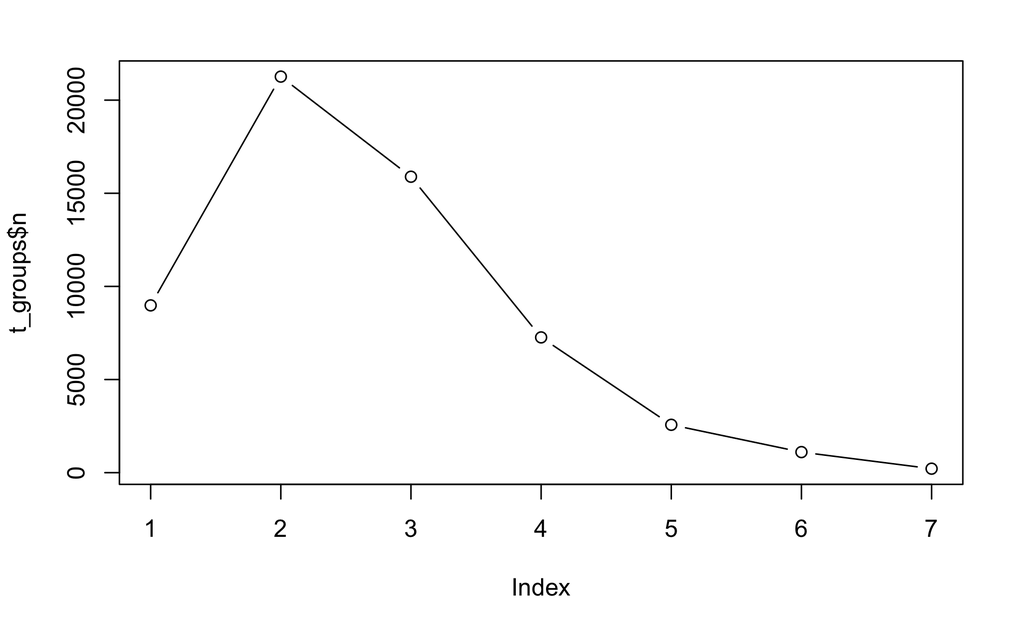

```r
# see how many trips in each time_group
isochrone_frame %>% group_by(time_groups) %>% summarise(n = n()) -> t_groups
plot(t_groups$n, type = 'b')
```

### Import the dissemination block shape file

```r
canada_shape <- st_read("../../data/census2016_DBS_shp/DB_Van_CMA/DB_Van_CMA.shp", stringsAsFactors = FALSE)
# select a greater metropolitan area
metropolitan_area <- "Vancouver"

# filter columns and rows
vancouver_shape <- data.frame(canada_shape[which(canada_shape$CMANAME == metropolitan_area), c(1, 28)])

# id to factor
vancouver_shape$DBUID <- as.factor(vancouver_shape$DBUID)

paste('Rows = ', nrow(vancouver_shape))
```

```
[1] "Rows =  15197"
```

```r
head(vancouver_shape)
```

|  | DBUID | geometry |
| --- | --- | --- |
| 1 | 59150244005 |  |
| 2 | 59150244008 |  |
| 3 | 59150372006 |  |
| 4 | 59150372007 |  |
| 5 | 59150373001 |  |
| 6 | 59150373002 |  |

## 2) Score Computation

Notes:

- We don’t scale the data before score computation because we care about the scale of time and standard deviation. We should use their values as is, otherwise scaling will give them equal weighing again when this is a bad assumption.
- Log normalizing the score isn’t important as the score visualization depends on the quantiles taken from the distribution of scores. Since log only shifts values, the visualizations will be identical.

```r
score_list <- list()
score_list_weighted<-list()
i <- 1

for (n in 1:4) {

  # we want average of all times so N must be undefined
  if (n == 4) { n <- NULL }

  # unweighted score
  score <- sum_score_fxn(ttm, nearest_n = n, weight = FALSE, log_normalize_score = FALSE)
  # weighted score
  score_weighted <- sum_score_fxn(ttm, nearest_n = n, weight = TRUE, log_normalize_score = FALSE)

  # append
  score_list[[i]] <- score
  score_list_weighted[[i]]<-score_weighted

  i <- i+1
}

scores_long_unweighted <- rbindlist(score_list) %>% arrange(fromId, nearest_n)
scores_long_weighted <- rbindlist(score_list_weighted) %>% arrange(fromId, nearest_n)

scores_long <- rbindlist(list(scores_long_weighted, scores_long_unweighted))

# Export scores to be used for calculating transit efficiency maps
write.csv(scores_long, '../../data/efficiency/initial_scores.csv', row.names = FALSE)
```

## 3) Dataset Wrangling Part II (NA Insertion)

Each origin(fromId) should have x different scores where x is defined by:

x = 2 weight options * 4 amenity options * 4 nearest options = 32

In addition to filling the empty NA rows for included IDs, there are also IDs that need to be re-added as not a single time was computed for these IDs.

```r
# values per ID (32)
x <- 2*4*4

paste0('SCORES FRAME')
```

```
[1] "SCORES FRAME"
```

```r
# HOW MANY ROWS TO FILL IN SCORES?
N <- uniqueN(scores_long$fromId) * x # expected rows
paste(glue('{nrow(scores_long)} of {N} rows filled ({round((nrow(scores_long) / N)*100, 2)}%)'))
```

```
[1] "458256 of 458976 rows filled (99.84%)"
```

```r
paste(N - nrow(scores_long), 'to fill.')
```

```
[1] "720 to fill."
```

```r
cat(paste0('\n')) # line break
```

```r
# HOW MANY ROWS TO ADD IN SCORES?
# existing IDs that weren't included in ttm
missing_blocks <- array(setdiff(origins$id, scores_long$fromId))
total_expected <- nrow(scores_long) + length(missing_blocks) * x
paste(glue('{nrow(scores_long)} of {total_expected} rows filled ({round((nrow(scores_long) / total_expected)*100, 2)}%)'))
```

```
[1] "458256 of 485584 rows filled (94.37%)"
```

```r
paste(length(missing_blocks)*x, 'to add')
```

```
[1] "27328 to add"
```

```r
cat(paste0('\n')) # line break
```

```r
paste0('ISOCHRONE FRAME')
```

```
[1] "ISOCHRONE FRAME"
```

```r
# HOW MANY ROWS TO FILL IN ISOCHRONE?
N <- uniqueN(isochrone_frame$fromId) * 4 # expected rows
paste(glue('{nrow(isochrone_frame)} of {N} rows filled ({round((nrow(isochrone_frame) / N)*100, 2)}%)'))
```

```
[1] "57282 of 57372 rows filled (99.84%)"
```

```r
paste(N - nrow(isochrone_frame), 'to fill.')
```

```
[1] "90 to fill."
```

```r
cat(paste0('\n')) # line break
```

```r
# HOW MANY ROWS TO ADD IN ISOCHRONE?
# existing IDs that weren't included in ttm
missing_blocks <- array(setdiff(origins$id, isochrone_frame$fromId))
total_expected <- nrow(isochrone_frame) + length(missing_blocks) * 4 # only 4 values per origin
paste(glue('{nrow(isochrone_frame)} of {total_expected} rows filled ({round((nrow(isochrone_frame) / total_expected)*100, 2)}%)'))
```

```
[1] "57282 of 60698 rows filled (94.37%)"
```

```r
paste(length(missing_blocks)*4, 'to add')
```

```
[1] "3416 to add"
```

```r
# fill NA for all existing origin IDs
filled_scores_long <- NA_table_filler(scores_long)

# add remaining NAs to filled_scores_long
all_scores_long <- NA_table_filler(filled_scores_long,
                                   custom_idx = missing_blocks)



# fill NA for all existing origin IDs
filled_isochrone_frame <- NA_table_filler(isochrone_frame,
                                          isochrone = TRUE)
# add missing NAs to isochrone frame
all_isochrone_frame <- NA_table_filler(filled_isochrone_frame,
                                       custom_idx = missing_blocks,
                                       isochrone=TRUE)
```

```r
# check isochrones
# there should be 4 counts per fromId
iso_id_counts <- all_isochrone_frame %>% group_by(fromId) %>% summarise(n = n())
unique(iso_id_counts$n)
```

```
[1] 4
```

```r
# check scores
# there should be 32 counts per fromId
score_id_counts <- all_scores_long %>% group_by(fromId) %>% summarise(n = n())
unique(score_id_counts$n)
```

```
[1] 32
```

Now lets add population data to the scores and isochrone frame

```r
# right join with origins to include origins without transit access

all_scores_long <- right_join(all_scores_long, origins, by = c('fromId' = 'id'))
all_isochrone_frame <- right_join(all_isochrone_frame, origins, by = c('fromId' = 'id'))
```

```r
## Export checkpoint
write.csv(all_scores_long, '../../data/html_mapping_data/scores_long.csv', row.names = FALSE)
write.csv(all_isochrone_frame, '../../data/html_mapping_data/isochrone_frame.csv', row.names = FALSE)
```

## 4) Interactive Visualization

```r
# join factor and geometry data
scores_viz_frame <- left_join(vancouver_shape, all_scores_long, by = c('DBUID' = 'fromId'))
isochrone_viz_frame <- left_join(vancouver_shape, all_isochrone_frame, by = c('DBUID' = 'fromId'))

# convert back to sf object
scores_viz_frame_sf <- st_as_sf(scores_viz_frame)
isochrone_viz_frame_sf <- st_as_sf(isochrone_viz_frame)

# convert to st object
scores_viz_frame_st <- st_transform(scores_viz_frame_sf, crs = 4326)
isochrone_viz_frame_st <- st_transform(isochrone_viz_frame_sf, crs = 4326)
```

Import bus stop file

```r
# Read Vancouver Station txt file
rawlocs <- read.csv(file="../../data/clean/stops.txt", head=TRUE,sep=",")
```

```r
station_locs <- rawlocs

station_locs <- station_locs[c("stop_id","stop_name","stop_lat","stop_lon")]

colnames(station_locs)[3] <- "latitude"

colnames(station_locs)[4] <- "longitude"

# Convert the columns imported as a factor to characters

station_locs$stop_id <- as.character(station_locs$stop_id)

station_locs$stop_name <- as.character(station_locs$stop_name)
head(station_locs)
```

|  | stop_id | stop_name | latitude | longitude |
| --- | --- | --- | --- | --- |
| 1 | 1 | Westbound Davie St @ Bidwell St | 49.28645 | -123.1404 |
| 2 | 11 | Eastbound Davie St @ Howe St | 49.27755 | -123.1270 |
| 3 | 14 | Eastbound Pacific Blvd @ Homer St | 49.27292 | -123.1255 |
| 4 | 21 | Eastbound E Pender St @ Carrall St | 49.28039 | -123.1038 |
| 5 | 22 | Northbound Columbia St @ E Pender St | 49.28077 | -123.1022 |
| 6 | 25 | Westbound Davie St @ Granville St | 49.27743 | -123.1265 |

```r
NA
```

```r
station_locs <-station_locs[!is.na(as.numeric(station_locs$stop_id)), ]
unique(station_locs$stop_id)%>%length()
```

```
[1] 8880
```

## 5) Map HTML Exports

```r
# exclue NA in type
type_name <- unique(scores_viz_frame_st$type)
level <- c(TRUE,FALSE)

for (amenity in type_name) {
  for (add_stop in level) {

  # 4 isochrone maps

    map_maker_isochrone(data = isochrone_viz_frame_st,bus_data =station_locs,amenity,add_stop, output_dir = '../../data/html_maps/isochrone_maps')

    for (weight in unique(scores_viz_frame_st$weight)) {
      for (nearest_n in unique(scores_viz_frame_st$nearest_n)) {


      # 32 others
        map_maker_scores(data = scores_viz_frame_st,bus_data =station_locs, amenity,add_stop=add_stop, weight=weight, nearest_n,output_dir = '../../data/html_maps/score_maps')
      }
    }
  }
}
```

```
[1] "Current Map: Gallery Transit Isochrone"
[1] "Current Map: Gallery Transit Isochrone with bus stops"
[1] "Current Map: Gallery - wt(yes) - n(1)"
[1] "Current Map: Gallery - wt(yes) - n(1)-bus"
[1] "Current Map: Gallery - wt(yes) - n(2)"
[1] "Current Map: Gallery - wt(yes) - n(2)-bus"
[1] "Current Map: Gallery - wt(yes) - n(3)"
[1] "Current Map: Gallery - wt(yes) - n(3)-bus"
[1] "Current Map: Gallery - wt(yes) - n(ALL)"
[1] "Current Map: Gallery - wt(yes) - n(ALL)-bus"
[1] "Current Map: Gallery - wt(no) - n(1)"
[1] "Current Map: Gallery - wt(no) - n(1)-bus"
[1] "Current Map: Gallery - wt(no) - n(2)"
[1] "Current Map: Gallery - wt(no) - n(2)-bus"
[1] "Current Map: Gallery - wt(no) - n(3)"
```

[output cut: 93 more lines]